# Lecture 6 bis : Additional exercices

*December, 2021 - François HU*

*Master of Science - EPITA*

*This lecture is available here: https://curiousml.github.io/*

[figure not shown]

# Exercices

These exercices are considered "normal-hard" exercices.

## Exercice 1: lists

Create a function `insert`, that produces the following results:

```
>>> l = [0, 9, 3, 10]
>>> print(insert(l, -1, 1))
[0, -1, 9, 3, 10]
>>> print(insert(l, -1, 2))
[0, 9, -1, 3, 10]
>>> print(insert(l, "epita", 4))
[0, 9, 3, 10, 'epita']
>>> print(insert(l, "epita", 10))
[0, 9, 3, 10, 'epita']
>>> print(l)
[0, 9, 3, 10]
```

```python
def insert(l, v, i):
    l = l[:i] + [v] + l[i:]
    return(l)
```

```python
l = [0, 9, 3, 10]
print(insert(l, -1, 1))
print(insert(l, -1, 2))
print(insert(l, "epita", 4))
print(insert(l, "epita", 10))
print(l)
```

```
[0, -1, 9, 3, 10]
[0, 9, -1, 3, 10]
[0, 9, 3, 10, 'epita']
[0, 9, 3, 10, 'epita']
[0, 9, 3, 10]
```

## Exercice 2: dictionaries

we have the following list of dictionaries

```python
paris = [{"District": 3, "Date":2007, "Pop":34576},
         {"District": 5, "Date":2007, "Pop":62664},
         {"District": 6, "Date":2007, "Pop":45332},
         {"District": 7, "Date":2007, "Pop":57410},
         {"District": 8, "Date":2007, "Pop":39165},
         {"District": 9, "Date":2007, "Pop":58632},
         {"District": 10, "Date":2007, "Pop":93373},
         {"District": 11, "Date":2007, "Pop":151421},
         {"District": 12, "Date":2007, "Pop":142425},
         {"District": 13, "Date":2007, "Pop":179213},
         {"District": 14, "Date":2007, "Pop":134382},
         {"District": 15, "Date":2007, "Pop":232247},
         {"District": 16, "Date":2007, "Pop":159706},
         {"District": 17, "Date":2007, "Pop":164673},
         {"District": 18, "Date":2007, "Pop":191523},
         {"District": 19, "Date":2007, "Pop":184038},
         {"District": 20, "Date":2007, "Pop":194018}]
```

1. write a script that add a field `Rounded_pop` which discard the last 3 digits. For example we transform the value `34576` to `34`

```python
for p in paris:
    p["Rounded_pop"] = p["Pop"]//1000
paris
```

```
[{'District': 3, 'Date': 2007, 'Pop': 34576, 'Rounded_pop': 34},
 {'District': 5, 'Date': 2007, 'Pop': 62664, 'Rounded_pop': 62},
 {'District': 6, 'Date': 2007, 'Pop': 45332, 'Rounded_pop': 45},
 {'District': 7, 'Date': 2007, 'Pop': 57410, 'Rounded_pop': 57},
 {'District': 8, 'Date': 2007, 'Pop': 39165, 'Rounded_pop': 39},
 {'District': 9, 'Date': 2007, 'Pop': 58632, 'Rounded_pop': 58},
 {'District': 10, 'Date': 2007, 'Pop': 93373, 'Rounded_pop': 93},
 {'District': 11, 'Date': 2007, 'Pop': 151421, 'Rounded_pop': 151},
 {'District': 12, 'Date': 2007, 'Pop': 142425, 'Rounded_pop': 142},
 {'District': 13, 'Date': 2007, 'Pop': 179213, 'Rounded_pop': 179},
 {'District': 14, 'Date': 2007, 'Pop': 134382, 'Rounded_pop': 134},
 {'District': 15, 'Date': 2007, 'Pop': 232247, 'Rounded_pop': 232},
 {'District': 16, 'Date': 2007, 'Pop': 159706, 'Rounded_pop': 159},
 {'District': 17, 'Date': 2007, 'Pop': 164673, 'Rounded_pop': 164},
 {'District': 18, 'Date': 2007, 'Pop': 191523, 'Rounded_pop': 191},
 {'District': 19, 'Date': 2007, 'Pop': 184038, 'Rounded_pop': 184},
 {'District': 20, 'Date': 2007, 'Pop': 194018, 'Rounded_pop': 194}]
```

1. write a script that store the values of `Rounded_pop` into a list named `populations`

```python
populations = []
for p in paris:
    populations.append(p["Rounded_pop"])
populations
```

```
[34, 62, 45, 57, 39, 58, 93, 151, 142, 179, 134, 232, 159, 164, 191, 184, 194]
```

1. sort by ascending order the list `populations`

```python
populations.sort()
populations
```

```
[34, 39, 45, 57, 58, 62, 93, 134, 142, 151, 159, 164, 179, 184, 191, 194, 232]
```

## Exercice 3: strings

we have the following list of strings

```python
list_of_strings = [
    'EPITA', 'propose', 'trois', 'programmes',
    'spécialisés', 'Master', 'of', 'Science',
    'dans', 'un', 'environnement', 'international.',
    'Cette', 'formation', 'professionnalisante', 'de',
    '18', 'mois', 'intégralement', 'en', 'anglais',
    'pour','les','étudiants','français', 'et', 'internationaux,',
    'permet', 'de', 'se', 'spécialiser', 'dans', 'un',
    'domaine', 'après', '3', 'ou', '4', 'ans', 'd’études.']
```

Write a script that create a variable named `text` which concatenante the items of `list_of_strings` with **exactly one space between words**.

```python
text = ' '.join(list_of_strings)
text
```

```
'EPITA propose trois programmes spécialisés Master of Science dans un environnement international. Cette formation professionnalisante de 18 mois intégralement en anglais pour les étudiants français et internationaux, permet de se spécialiser dans un domaine après 3 ou 4 ans d’études.'
```

```python
# alternatively

text = list_of_strings[0]
for s in list_of_strings[1:]:
    text += ' '
    text += s
text
```

```
'EPITA propose trois programmes spécialisés Master of Science dans un environnement international. Cette formation professionnalisante de 18 mois intégralement en anglais pour les étudiants français et internationaux, permet de se spécialiser dans un domaine après 3 ou 4 ans d’études.'
```

## Exercice 4: arrays

1. Generate the following array **without explicit loops** and **without manually fill in the numbers**. We will name it `arr1`:

```
[[  0  25 100 225 400]
 [  1  36 121 256 441]
 [  4  49 144 289 484]
 [  9  64 169 324 529]
 [ 16  81 196 361 576]]
```

```python
import numpy as np

arr1 = np.arange(25).reshape(5,-1).T**2
arr1
```

```
array([[  0,  25, 100, 225, 400],
       [  1,  36, 121, 256, 441],
       [  4,  49, 144, 289, 484],
       [  9,  64, 169, 324, 529],
       [ 16,  81, 196, 361, 576]])
```

1. Extract the diagonal values of `arr1` (do not generate it) and call it `diag1`

```
[  0,  36, 144, 324, 576]
```

```python
diag1 = arr1[np.arange(5), np.arange(5)]
diag1
```

```
array([  0,  36, 144, 324, 576])
```

1. From `arr1`, extract the submatrix:

```
[[225 100  25]
 [289 144  49]
 [256 121  36]]
```

and name it `subarr1`.

```python
subarr1 = arr1[[0, 2, 1], :][:, [3, 2, 1]]
print(subarr1)
```

```
[[225 100  25]
 [289 144  49]
 [256 121  36]]
```

## Exercice 5: arrays

1. Generate the following array **without explicit loops** and **without manually fill in the numbers**. We will name it `arr2`:

```
[[10  9  8  7  6]
 [ 9  8  7  6  5]
 [ 8  7  6  5  4]
 [ 7  6  5  4  3]
 [ 6  5  4  3  2]]
```

```python
arr = np.arange(5, 0, -1)
arr2 = np.tile(arr, (5, 1)).T + arr
print(arr2)
```

```
[[10  9  8  7  6]
 [ 9  8  7  6  5]
 [ 8  7  6  5  4]
 [ 7  6  5  4  3]
 [ 6  5  4  3  2]]
```

1. Replace all the even values of `arr2` by `0` without explicit loops. You should have:

   ```
   [[0 9 0 7 0]
   [9 0 7 0 5]
   [0 7 0 5 0]
   [7 0 5 0 3]
   [0 5 0 3 0]]
   ```

```python
arr2[arr2%2==0] = 0
print(arr2)
```

```
[[0 9 0 7 0]
 [9 0 7 0 5]
 [0 7 0 5 0]
 [7 0 5 0 3]
 [0 5 0 3 0]]
```

## Exercice 6: plotting

1. Generate and (scatter) plot 2000 random points in the space $[−10,0]×[1,2]$ with the color `orange`. You should have:

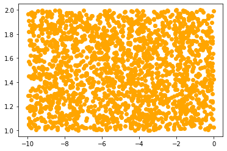

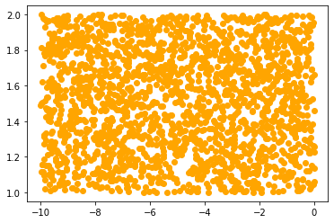

```python
import numpy as np
import matplotlib.pyplot as plt

n = 2000
x = -10 * np.random.rand(n)
y = np.random.rand(n) + 1

plt.scatter(x, y, color="orange");
```

1. color the points inside the space $[−4,-2]×[1.2,1.8]$ or $[−8,-6]×[1.2,1.8]$ by green. You should have:

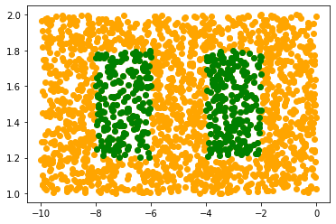

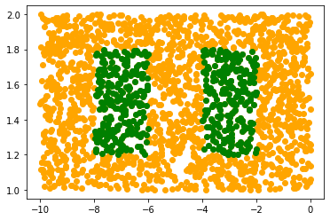

```python
import numpy as np
import matplotlib.pyplot as plt

ind1 = (x<=-2) & (x>=-4) & (y<=1.8) & (y>=1.2)
ind2 = (x<=-6) & (x>=-8) & (y<=1.8) & (y>=1.2)
x_green = x[ind1 | ind2]
y_green = y[ind1 | ind2]

plt.scatter(x, y, color="orange");
plt.scatter(x_green, y_green, color="green");
```

## Exercice 7: data manipulation

1. Import the `Iris` and `defra_consumption`datasets as dataframes and name them respectively `iris` and `cons`. You should have the following first 5 rows for each dataframe:

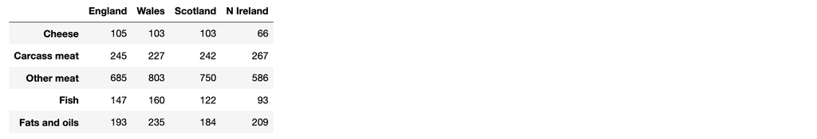

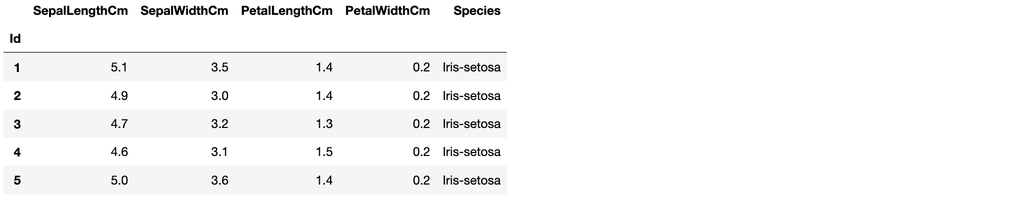

```python
import pandas as pd

cons = pd.read_csv('data/defra_consumption.csv', sep=';', index_col=0)
iris = pd.read_csv('data/Iris.csv', sep=',', index_col="Id")
```

```python
cons.head()
```

|  | England | Wales | Scotland | N Ireland |
| --- | --- | --- | --- | --- |
| Cheese | 105 | 103 | 103 | 66 |
| Carcass meat | 245 | 227 | 242 | 267 |
| Other meat | 685 | 803 | 750 | 586 |
| Fish | 147 | 160 | 122 | 93 |
| Fats and oils | 193 | 235 | 184 | 209 |

```python
iris.head()
```

| Id | SepalLengthCm | SepalWidthCm | PetalLengthCm | PetalWidthCm | Species |
| --- | --- | --- | --- | --- | --- |
| 1 | 5.1 | 3.5 | 1.4 | 0.2 | Iris-setosa |
| 2 | 4.9 | 3.0 | 1.4 | 0.2 | Iris-setosa |
| 3 | 4.7 | 3.2 | 1.3 | 0.2 | Iris-setosa |
| 4 | 4.6 | 3.1 | 1.5 | 0.2 | Iris-setosa |
| 5 | 5.0 | 3.6 | 1.4 | 0.2 | Iris-setosa |

1. For the dataframe `iris` (aside from the column `species`):
   - discard the `Cm` at the end of each column name
   - convert values to minimeter (instead of centimiter)

```python
iris.columns = ["SepalLength", "SepalWidth", "PetalLength", "PetalWidth", "Species"]
iris.iloc[:, :-1] *= 10
iris.head()
```

| Id | SepalLength | SepalWidth | PetalLength | PetalWidth | Species |
| --- | --- | --- | --- | --- | --- |
| 1 | 51.0 | 35.0 | 14.0 | 2.0 | Iris-setosa |
| 2 | 49.0 | 30.0 | 14.0 | 2.0 | Iris-setosa |
| 3 | 47.0 | 32.0 | 13.0 | 2.0 | Iris-setosa |
| 4 | 46.0 | 31.0 | 15.0 | 2.0 | Iris-setosa |
| 5 | 50.0 | 36.0 | 14.0 | 2.0 | Iris-setosa |

1. For the dataframe `cons`, convert columns to percentages of the totals. Therefore the first row should be:

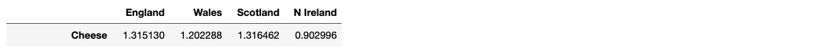

```python
cons = (cons/cons.sum(axis=0))*100
cons.head()
```

|  | England | Wales | Scotland | N Ireland |
| --- | --- | --- | --- | --- |
| Cheese | 1.315130 | 1.202288 | 1.316462 | 0.902996 |
| Carcass meat | 3.068637 | 2.649702 | 3.093047 | 3.653031 |
| Other meat | 8.579659 | 9.373176 | 9.585890 | 8.017513 |
| Fish | 1.841182 | 1.867632 | 1.559305 | 1.272404 |
| Fats and oils | 2.417335 | 2.743084 | 2.351738 | 2.859488 |